# Modelling

#### Packages

```r
library(tidyverse)
library(tidymodels)
library(ggplot2)
library(tseries)
library(ggfortify)
library(astsa)
library(gridExtra)
library(forecast)
```

#### Loading the datasets

```r
#monthly data without imputations
m_df = read_csv('../data/processed/month_df.csv')
```

```r
#monthly data with imputations
i_df = read_csv('../data/processed/month_df_imputed.csv')
```

# SARIMA

For SARIMA, we will use the imputed data

## Train and Test split

```r
split_val = 0.7
t_split = initial_time_split(i_df, prop=split_val)
t_train = training(t_split)
t_test = testing(t_split)

#get the min and max of start dates and end dates
train_date_min = c(t_train %>% head(1) %>% pull(year), t_train %>% head(1) %>% pull(month))
train_date_max = c(t_train %>% tail(1) %>% pull(year), t_train %>% tail(1) %>% pull(month))
test_date_min = c(t_test %>% head(1) %>% pull(year), t_test %>% head(1) %>% pull(month))
test_date_max = c(t_test %>% tail(1) %>% pull(year), t_test %>% tail(1) %>% pull(month))

train_ts = ts(t_train %>% pull(magnitude), start=train_date_min,end=train_date_max,frequency=12)
test_ts = ts(t_test %>% pull(magnitude), start=test_date_min,end=test_date_max,frequency=12)

#boxcox transformation
lambda = BoxCox.lambda(train_ts) #find optimal lambda for train_ts
bctrain = BoxCox(train_ts,lambda)

dtrain = diff(train_ts)
dbctrain = diff(bctrain)
ddbctrain = diff(dbctrain,12)
```

*Time series Plots*:

```r
train_plot = ggplot2::autoplot(train_ts, main='Monthly Earthquake data', ts.colour='black', ylab='magnitude',xlab='year')
```

```r
bctrain_plot = ggplot2::autoplot(bctrain, main='BoxCox Monthly Earthquake data', ts.colour='black', ylab='BoxCox(magnitude)',xlab='year')
```

```r
dtrain_plot = ggplot2::autoplot(dtrain, main='Differenced BoxCox Monthly Earthquake data', ts.colour='black', ylab='diff(log(magnitude))',xlab='year')
```

```r
ddtrain_plot = ggplot2::autoplot(ddbctrain, main='12 Differenced BoxCox Monthly Earthquake data', ts.colour='black', ylab='diff(log(magnitude))',xlab='year')
```

```r
grid.arrange(train_plot,bctrain_plot,dtrain_plot,ddtrain_plot)
```

[output not shown]

*Augmented Dickey-Fuller test*:

```r
adf.test(train_ts)
```

[output not shown]

From the Augmented Dickey-Fuller Test, we can say that there exists a unit root on the time series. This means that we reject the null hypothesis and conclude that there the time series is stationary, and possible with a trend

*QQ-plot:*

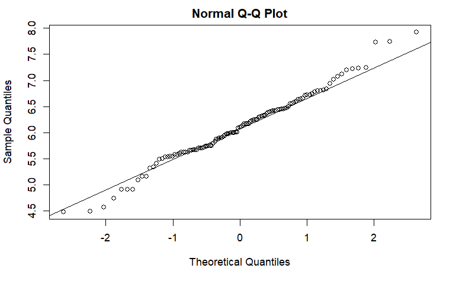

```r
qqnorm(train_ts)
qqline(train_ts)
```

From the data, it’s slightly skewed at the tails, but it looks relatively normal.

*ACF & PACF*:

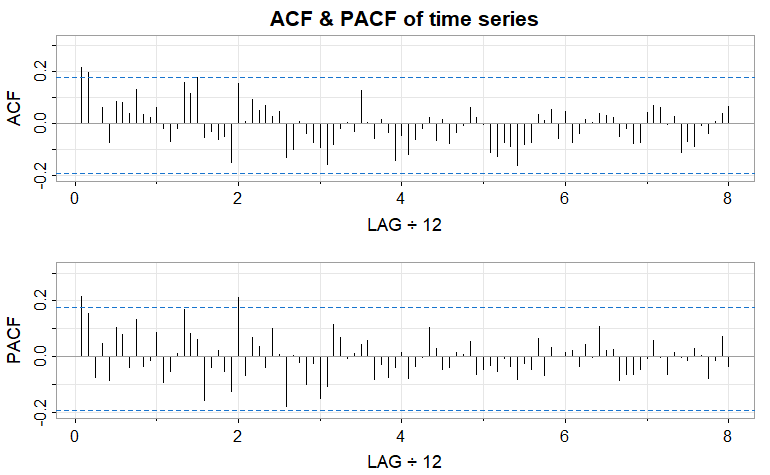

```r
train_acf2 = acf2(train_ts, main='ACF & PACF of time series',12*8)
```

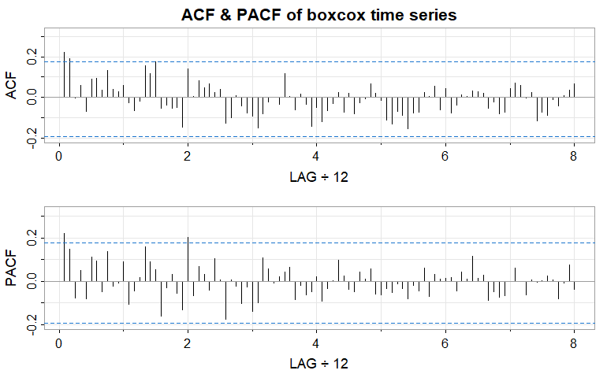

```r
bctrain_acf2 = acf2(bctrain,main='ACF & PACF of boxcox time series',12*8)
```

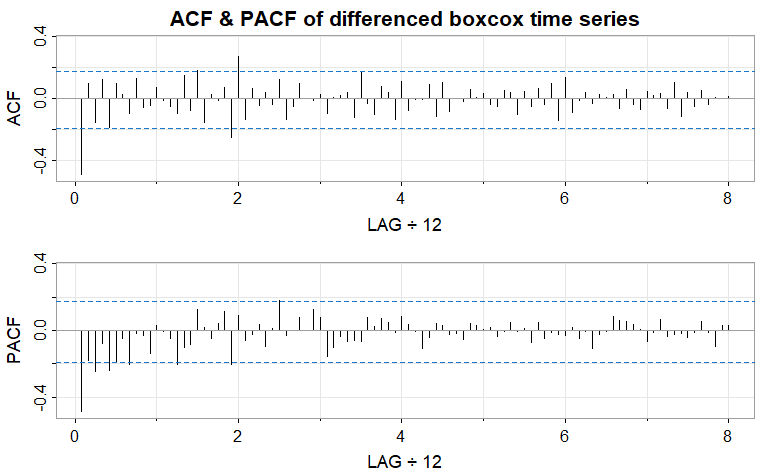

```r
dtrain_acf2 = acf2(dtrain,main='ACF & PACF of differenced boxcox time series',12*8)
```

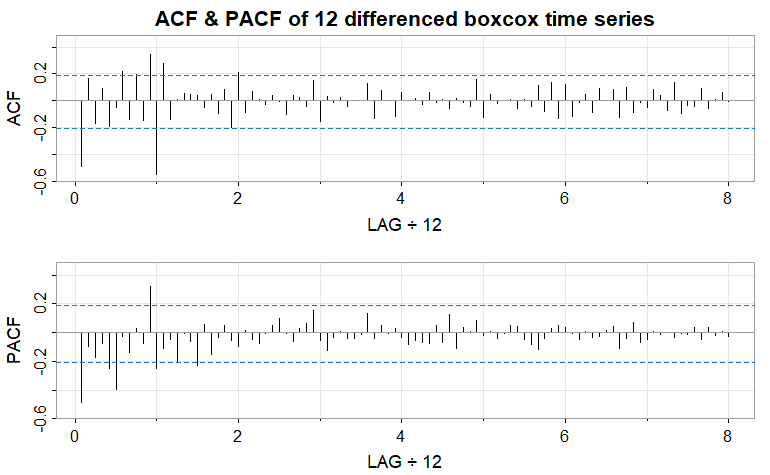

```r
ddtrain_acf = acf2(ddbctrain,main='ACF & PACF of 12 differenced boxcox time series',12*8)
```

From these ACF and PACF, there are some lags worth noting:

Boxcox time series: 1. ACF seems to tail off 2. PACF seems to cut off at lag 24 (2 years)

This implies possible models: AR(24)

Differenced time series: 1. ACF seems to cut off at lag 24 (2 years) 2. PACF seems to tail off

This implies possible models: MA(24)

Possible models:

12 Differenced time series: 1. ACF seems to cut off at lag 12 (1 year) 2. PACF seems to tail off

This implies possible models: MA(12)

Time series:

[figure not shown]

```r
par(mfrow=c(2,1))
k=kernel('modified.daniell',3)
e.per = mvspec(bctrain, taper=0, log="no", main='Periodogram')
e.per.smo = mvspec(bctrain, k,taper=0.5, log="no", main='Smoothed Periodogram | taper = 0.5')
```

## Fitting SARIMA models

*AR(24) on bctrain*

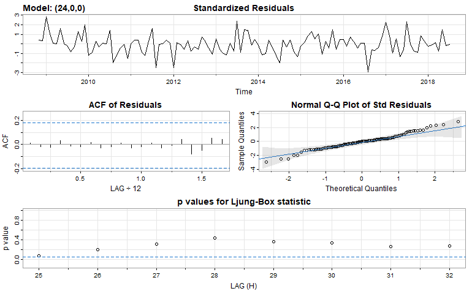

```r
set.seed(123)
#AR(2)
s_fit_1 = sarima(bctrain, 24,0,0)
```

```r
s_fit_1
```

It seems like this fit quite well. The residuals doesn’t have a clear pattern! This is good! The standard residuals are also relatively normal.

Let’s try with seasonality:

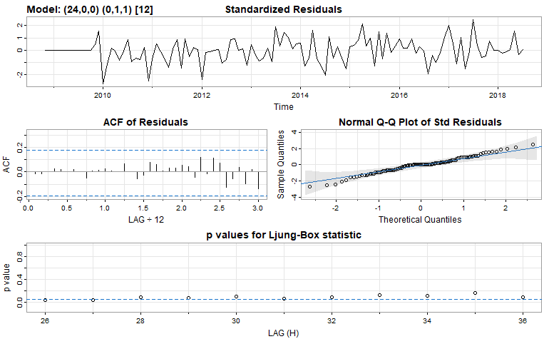

```r
set.seed(123)
s_fit1_seasonal = sarima(bctrain, 24,0,0,P=0,D=1,Q=1,S=12)
```

```r
s_fit1_seasonal
```

The p-values for Ljung-Box statistics aren’t significant, and there seems to be a trend on the residuals. This could mean that the model doesn’t fit or that there isn’t a seasonality portion.

*MA(24) on differenced time series*

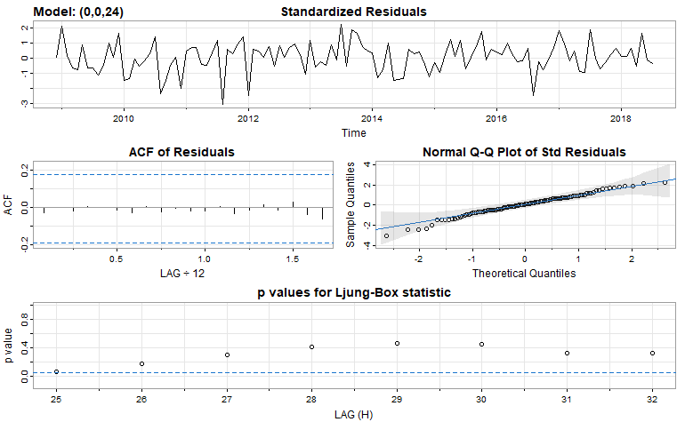

```r
s_fit_2 = sarima(dtrain, 0,0,24)
```

```r
s_fit_2
```

This looks even better! The residuals looks more and more like white noise. And the residuals ACF looks like white noise and p-values are significant.

**MA(12) on 12 differenced time series:**

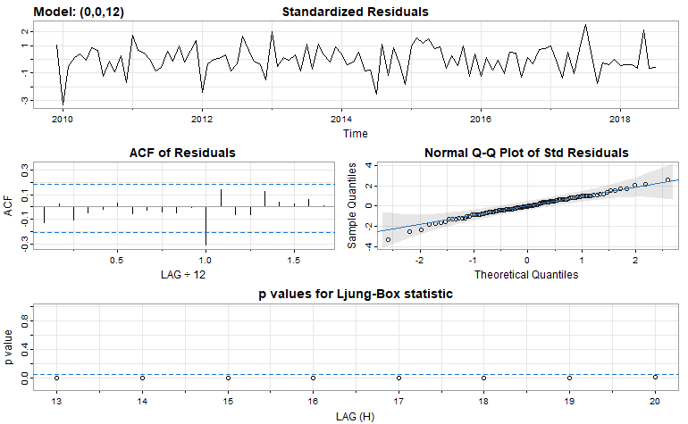

```r
s_fit_3= sarima(ddbctrain, 0,0,12)
```

```r
s_fit_3
```

From the residuals ACF, we can see that there is a significant peak at Residuals ACF, and that the p-values for the LB-statistic aren’t significant. This shows a bad fit for the earthquake data.

So far the model MA(24) works really well with the data. Let’s try AUTO ARIMA on the differenced time series.

*Auto Arima*:

```r
s_fit_auto = auto.arima(dtrain, seasonal=TRUE,num.cores = 8,approximation=FALSE)
s_fit_auto
```

[output not shown]

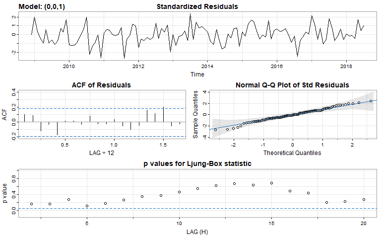

```r
s_fit_auto_sarima = sarima(dtrain,0,0,1)
```

```r
s_fit_auto_sarima
```

We will stick with the MA(24) model. Let’s use it to forecast and calculate accuracy.

*Forecasting:*

Let’s try forecasting 5 months.

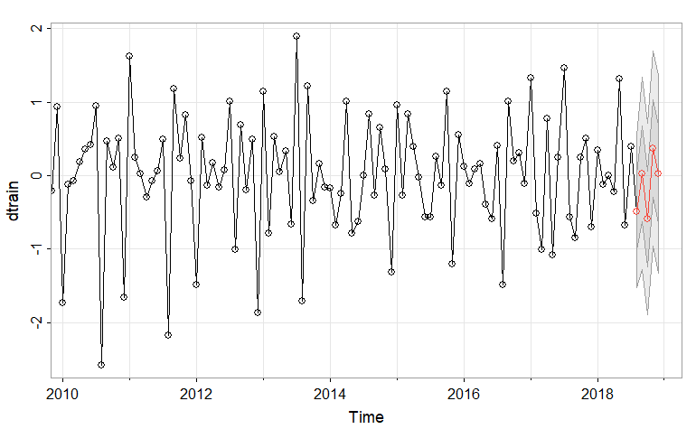

```r
set.seed(123)
sarima.for(dtrain, 5, 0,0,24)
```

Let’s compare to our testing set to check prediction error

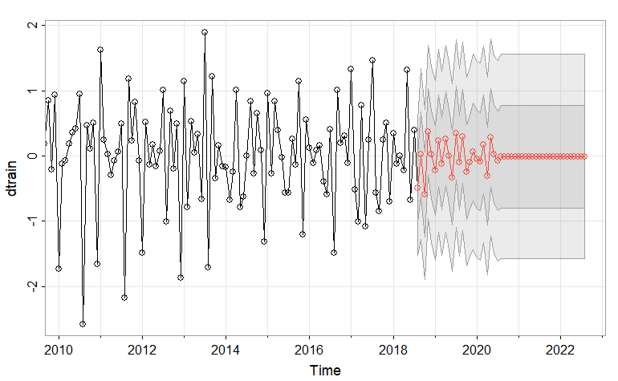

```r
set.seed(123)

#diff and boxcox testing set
dtest = diff(BoxCox(test_ts,lambda))

n= length(dtest)
#get the predictions for 50 months to check with testing set
s_fit_2.for = sarima.for(dtrain, n, 0,0,24)
```

```r
df_pred = tibble(actual=c(dtest),pred=c(s_fit_2.for$pred))
```

RMSE:

```r
rmse(df_pred, truth=actual, estimate=pred)
```

| .metric | .estimator | .estimate |
| --- | --- | --- |
| rmse | standard | 2.528375 |

The RMSE is not bad! Let’s try for the AUTOARIMA.

*AUTOARIMA Forecasting:*

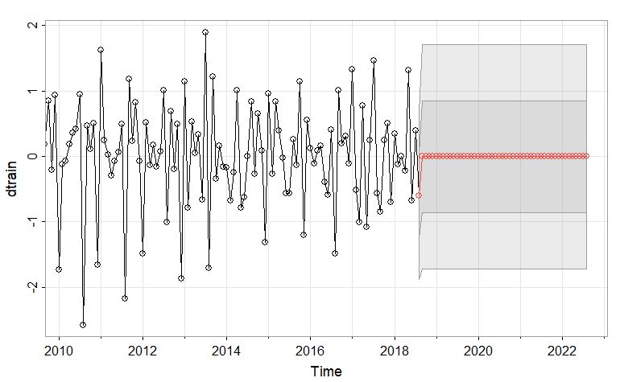

```r
set.seed(123)

#diff and boxcox testing set
dtest = diff(BoxCox(test_ts,lambda))

n= length(dtest)
#get the predictions for 50 months to check with testing set
s_fit_auto.for = sarima.for(dtrain, n, 0,0,1)
```

```r
df_pred_auto = tibble(actual=c(dtest),pred=c(s_fit_auto.for$pred))
```

```r
rmse(df_pred_auto, truth=actual, estimate=pred)
```

| .metric | .estimator | .estimate |
| --- | --- | --- |
| rmse | standard | 2.534802 |

It is slightly worse. Thus our best fit model is SARIMA.

# Local Level State Space Model

Since state space model can work with missing data, let’s not force any imputations and use our unimputed data.

```r
split_val = 0.7
t_split = initial_time_split(m_df, prop=split_val)
t_train = training(t_split)
t_test = testing(t_split)

#get the min and max of start dates and end dates
train_date_min = c(t_train %>% head(1) %>% pull(year), t_train %>% head(1) %>% pull(month))
train_date_max = c(t_train %>% tail(1) %>% pull(year), t_train %>% tail(1) %>% pull(month))
test_date_min = c(t_test %>% head(1) %>% pull(year), t_test %>% head(1) %>% pull(month))
test_date_max = c(t_test %>% tail(1) %>% pull(year), t_test %>% tail(1) %>% pull(month))

train_ts2 = ts(t_train %>% pull(magnitude), start=train_date_min,end=train_date_max,frequency=12)
test_ts2 = ts(t_test %>% pull(magnitude), start=test_date_min,end=test_date_max,frequency=12)

#boxcox transformation
lambda2 = BoxCox.lambda(train_ts2) #find optimal lambda for train_ts
bctrain2 = BoxCox(train_ts2,lambda2)

dtrain2 = diff(train_ts)
dbctrain2 = diff(bctrain)
ddbctrain2 = diff(dbctrain,12)
```

Filtering and Smoothing

```r
#initialize initial parameters
mu0 = 0
A=1
Sigma0 = 1
Phi = 1
sQ = 1
sR = 1
#estimating parameters using EM algorithm
par = EM(bctrain2, A=A, mu0=mu0, Sigma0 = Sigma0, Phi=0.01, Q=0.01, R=0.01)
#filtering and smoothing
ks = Ksmooth(bctrain2, A=A, mu0=par$mu0, Sigma0 = par$Sigma0, Phi=par$Phi, sQ=par$Q, sR=par$R)
```

```r
#code from pg. 302 from textbook

Time = 1:length(bctrain2)

plot(Time, bctrain2, main='Predict',ylim=c(-15,50))
lines(ks$Xp)
```

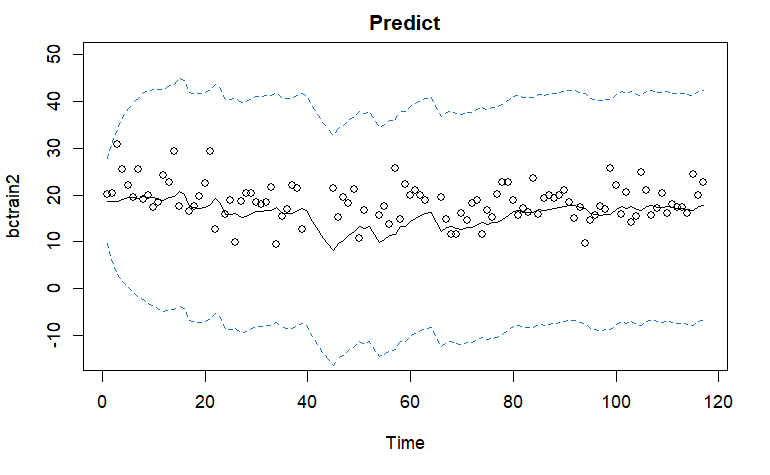

```r
lines(ks$Xp+2*sqrt(ks$Pp), lty=2, col=4)
lines(ks$Xp-2*sqrt(ks$Pp), lty=2, col=4)
```

```r
plot(Time, bctrain2, main='Filter',ylim=c(-15,50))
lines(ks$Xf)
```

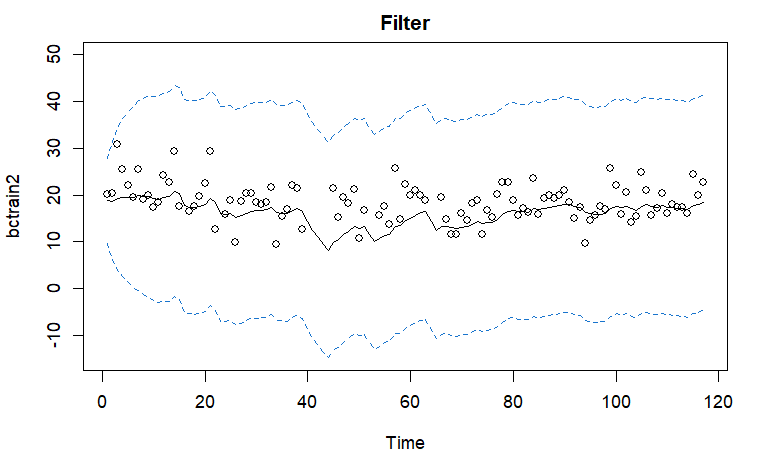

```r
lines(ks$Xf+2*sqrt(ks$Pf), lty=2, col=4)
lines(ks$Xf-2*sqrt(ks$Pf), lty=2, col=4)
```

```r
plot(Time, bctrain2,ylim=c(-15,50),
main='Smooth')
lines(ks$Xs)
```

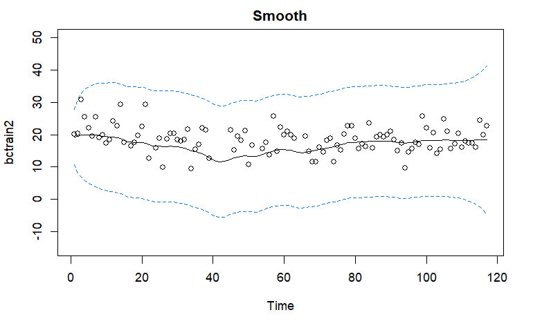

```r
lines(ks$Xs+2*sqrt(ks$Ps), lty=2, col=4)
lines(ks$Xs-2*sqrt(ks$Ps), lty=2, col=4)
```